# Applied Data Analysis Homework 4

Kevin Sanchez

5/12/2020

```r
library(dplyr)
library(tidyverse)
library(patchwork)
library(scales)
library(collapse)
library(BBmisc)
library(devtools)
remotes::install_github("joachim-gassen/tidycovid19")
library(tidycovid19)

merged <- download_merged_data(cached = TRUE)
```

```
## done. Timestamp is 2020-05-13 13:00:30
```

[output not shown]

[output not shown]

[output not shown]

[output not shown]

[output not shown]

[output not shown]

[output not shown]

[output not shown]

[output not shown]

[output not shown]

[output not shown]

[output not shown]

[output not shown]

[output not shown]

[output not shown]

[output not shown]

[output not shown]

[output not shown]

[output not shown]

[output not shown]

[output not shown]

[output not shown]

[output not shown]

```r
merged <- merged %>%
  group_by(country, iso3c) %>%
  arrange(country, iso3c, date) %>%
  mutate(
    confirmed = ifelse(is.na(confirmed), 0, confirmed),
    deaths = ifelse(is.na(deaths), 0, deaths),
    recovered = ifelse(is.na(recovered), 0, recovered)
  ) %>%
  mutate(
    daily_confirmed = confirmed - lag(confirmed, n = 1),
    daily_deaths = deaths - lag(deaths, n = 1),
    daily_recovered = recovered - lag(recovered, n = 1)
  ) %>%
  mutate(
    daily_confirmed = replace_na(daily_confirmed, 0),
    daily_deaths = replace_na(daily_deaths, 0),
    daily_recovered = replace_na(daily_recovered, 0)
  ) %>%
  ungroup() %>%
  arrange(country, iso3c, date)

add_world1 <- merged %>%
  group_by(date) %>%
  arrange(date) %>%
  summarize(
    country = "World", iso3c = NA,
    confirmed = sum(confirmed, na.rm = TRUE),
    deaths = sum(deaths, na.rm = TRUE),
    recovered = sum(recovered, na.rm = TRUE),
    timestamp = fmode(timestamp)
  ) %>%
  mutate(
    daily_confirmed = confirmed - lag(confirmed, n = 1),
    daily_deaths = deaths - lag(deaths, n = 1),
    daily_recovered = recovered - lag(recovered, n = 1)
  ) %>%
  mutate(
    daily_confirmed = replace_na(daily_confirmed, 0),
    daily_deaths = replace_na(daily_deaths, 0),
    daily_recovered = replace_na(daily_recovered, 0)
  ) %>%
  ungroup() %>%
  arrange(country, iso3c, date)

add_world2 <- merged %>%
  group_by(country, iso3c) %>%
  summarize(
    population = fmode(population),
    land_area_skm = fmode(land_area_skm),
    timestamp = fmode(timestamp)
  ) %>%
  ungroup() %>%
  summarize(
    country = "World", iso3c = NA,
    population = sum(population, na.rm = TRUE),
    land_area_skm = sum(land_area_skm, na.rm = TRUE)
  ) %>%
  mutate(pop_density = population / land_area_skm)

add_world <- left_join(add_world1, add_world2, by = c("country", "iso3c"))
merged <- bind_rows(merged, add_world)

cv_data <- pivot_longer(merged,
  cols = c(
    "confirmed", "deaths", "recovered",
    "daily_confirmed", "daily_deaths", "daily_recovered"
  ),
  names_to = "variable", values_to = "cases"
) %>%
  arrange(country, variable, date) %>%
  rename(area = land_area_skm, density = pop_density) %>%
  mutate(rate = cases / population * 10^6) %>%
  filter(date < "2020-05-11")

cv_summary <- function(d, country_list = "World",
                       plot = TRUE, facet = "country",
                       status = c("confirmed", "deaths", "recovered")) {

  my_palette <- c(
    "#5B1A18", "#FD6467", "#F1BB7B", "#D67236",
    "#0F0D0E", "#9986A5", "#79402E", "#CCBA72", "#D9D0D3", "#8D8680",
    "#EAD3BF", "#AA9486", "#B6854D", "#39312F", "#1C1718"
  )

  if (facet == "country") {
    fill <- "variable"
    n <- length(unique(d$variable)) / 2
  }

  if (facet == "variable") {
    fill <- "country"
    n <- length(country_list)
  }

  if ("All" %in% country_list) {
    country_list <- unique(d$country)
    country_list <- setdiff(country_list, "World")
  }

  if ("World" %in% country_list) {
    d <- d %>% filter(country %in% country_list)

    totals <- d %>%
      group_by(variable) %>%
      summarize(
        country = "World",
        cases = max(cases),
        population = max(population),
        area = max(area),
        density = max(density),
        rate = max(rate, na.rm = TRUE),
        on = max(date)
      ) %>%
      select(country, variable, cases, population, area, density, rate, on) %>%
      arrange(variable) %>%
      ungroup()
  }

  if ("World" %nin% country_list) {
    d <- d %>% filter(country %in% country_list)
    totals <- d %>%
      group_by(country, variable) %>%
      summarize(
        cases = max(cases),
        population = max(population),
        area = max(area),
        density = max(density),
        rate = max(rate, na.rm = TRUE),
        on = max(date),
        gdp_capita = fmode(gdp_capita),
        income = fmode(income),
        life_expectancy = fmode(life_expectancy),
        max_sd = max(soc_dist),
        max_mr = max(mov_rest)
      ) %>%
      select(
        country, variable, cases, population, area, density, rate,
        gdp_capita, income, life_expectancy, max_sd, max_mr, on
      ) %>%
      arrange(country, variable) %>%
      ungroup()
  }

  if (plot == TRUE) {
    cc <- filter(d, variable %in% status)
    cum_cases_plot <- ggplot(
      data = cc,
      aes(
        x = date, y = cases + 1, color = .data[[fill]],
        fill = .data[[fill]]
      )
    ) +
      geom_point(size = 0.5) +
      geom_line() +
      facet_wrap(~ .data[[facet]], ncol = 5) +
      xlab("Date") +
      ylab("Log Cumulative Cases") +
      scale_y_log10(
        breaks = trans_breaks("log10", function(x) 10^x),
        labels = trans_format("log10", math_format(10^.x))
      ) +
      scale_color_manual(
        aesthetics = c("color", "fill"),
        name = NULL, values = my_palette
      )

    dc <- filter(d, variable %in% paste0("daily_", status))
    daily_cases_plot <- ggplot(
      data = dc,
      aes(
        x = date, y = cases, color = .data[[fill]],
        fill = .data[[fill]]
      )
    ) +
      geom_point(size = 0.5) +
      geom_line() +
      facet_wrap(~ .data[[facet]], ncol = 5) +
      xlab("Date") +
      ylab("Daily Cases") +
      scale_color_manual(
        aesthetics = c("color", "fill"),
        name = NULL, values = my_palette
      )
  }

  if (plot == TRUE) {
    return(list(
      totals = totals,
      cum_cases_plot = cum_cases_plot,
      daily_cases_plot = daily_cases_plot
    ))
  } else {
    return(list(totals = totals))
  }
}
```

## Challenge 1

```r
cv_summary(cv_data)
```

```
## $totals
## # A tibble: 6 x 8
##   country variable          cases population      area density   rate on
##   <chr>   <chr>             <dbl>      <dbl>     <dbl>   <dbl>  <dbl> <date>
## 1 World   confirmed       4100108 7523799801    1.27e8    59.4 545.   2020-05-10
## 2 World   daily_confirmed   99113 7523799801    1.27e8    59.4  13.2  2020-05-10
## 3 World   daily_deaths       8856 7523799801    1.27e8    59.4   1.18 2020-05-10
## 4 World   daily_recovered   65439 7523799801    1.27e8    59.4   8.70 2020-05-10
## 5 World   deaths           282666 7523799801    1.27e8    59.4  37.6  2020-05-10
## 6 World   recovered       1407676 7523799801    1.27e8    59.4 187.   2020-05-10
##
## $cum_cases_plot
```

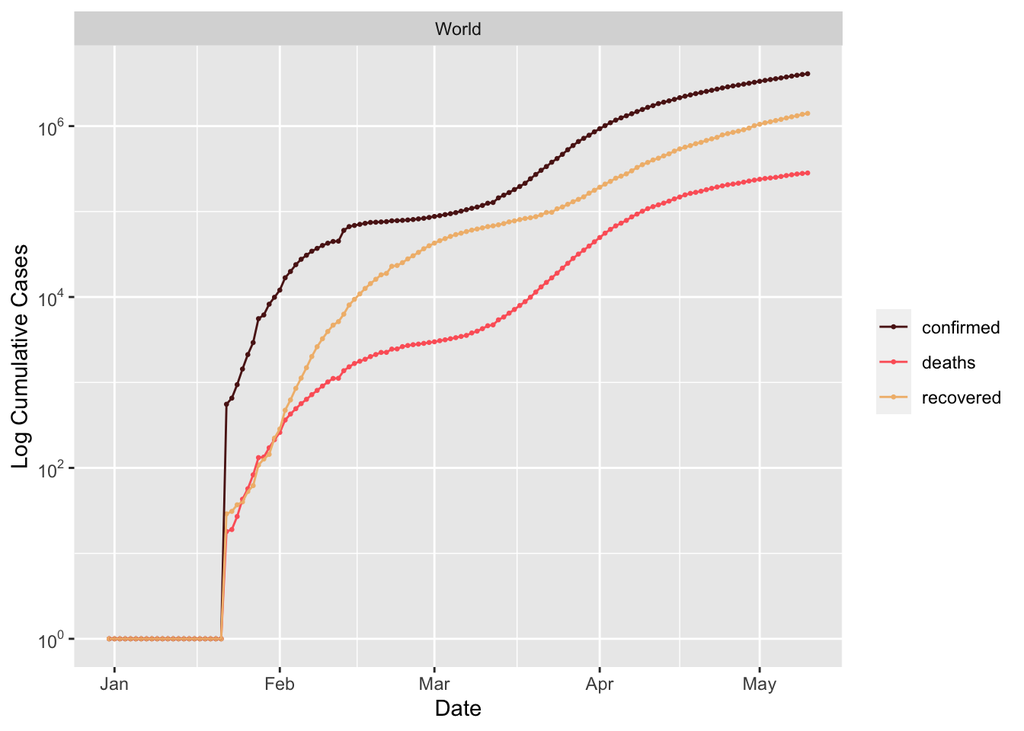

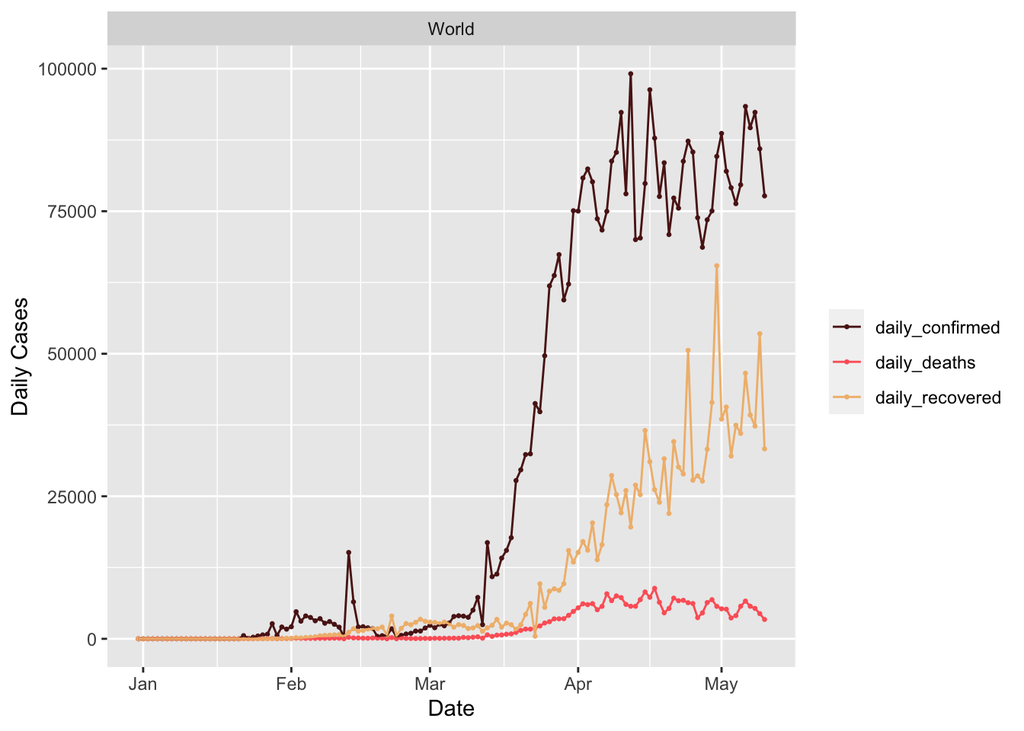

## Challenge 2

```r
cv_summary(cv_data, country_list = c("US", "United Kingdom", "Canada", "France",
  "Germany", "Italy", "Japan", "China", "Russia", "Iran"), facet = "country")
```

```
## $totals
## # A tibble: 54 x 13
##    country variable cases population   area density    rate gdp_capita income
##    <chr>   <chr>    <dbl>      <dbl>  <dbl>   <dbl>   <dbl>      <dbl> <chr>
##  1 Canada  confirm… 70091   37057765 9.09e6    4.08 1.89e+3     51392. High …
##  2 Canada  daily_c…  2778   37057765 9.09e6    4.08 7.50e+1     51392. High …
##  3 Canada  daily_d…   251   37057765 9.09e6    4.08 6.77e+0     51392. High …
##  4 Canada  daily_r…  1385   37057765 9.09e6    4.08 3.74e+1     51392. High …
##  5 Canada  deaths    4991   37057765 9.09e6    4.08 1.35e+2     51392. High …
##  6 Canada  recover… 32109   37057765 9.09e6    4.08 8.66e+2     51392. High …
##  7 China   confirm… 84010 1392730000 9.39e6  148.   6.03e+1      7753. Upper…
##  8 China   daily_c… 15136 1392730000 9.39e6  148.   1.09e+1      7753. Upper…
##  9 China   daily_d…  1290 1392730000 9.39e6  148.   9.26e-1      7753. Upper…
## 10 China   daily_r…  3995 1392730000 9.39e6  148.   2.87e+0      7753. Upper…
## # … with 44 more rows, and 4 more variables: life_expectancy <dbl>,
## #   max_sd <dbl>, max_mr <dbl>, on <date>
##
## $cum_cases_plot
```

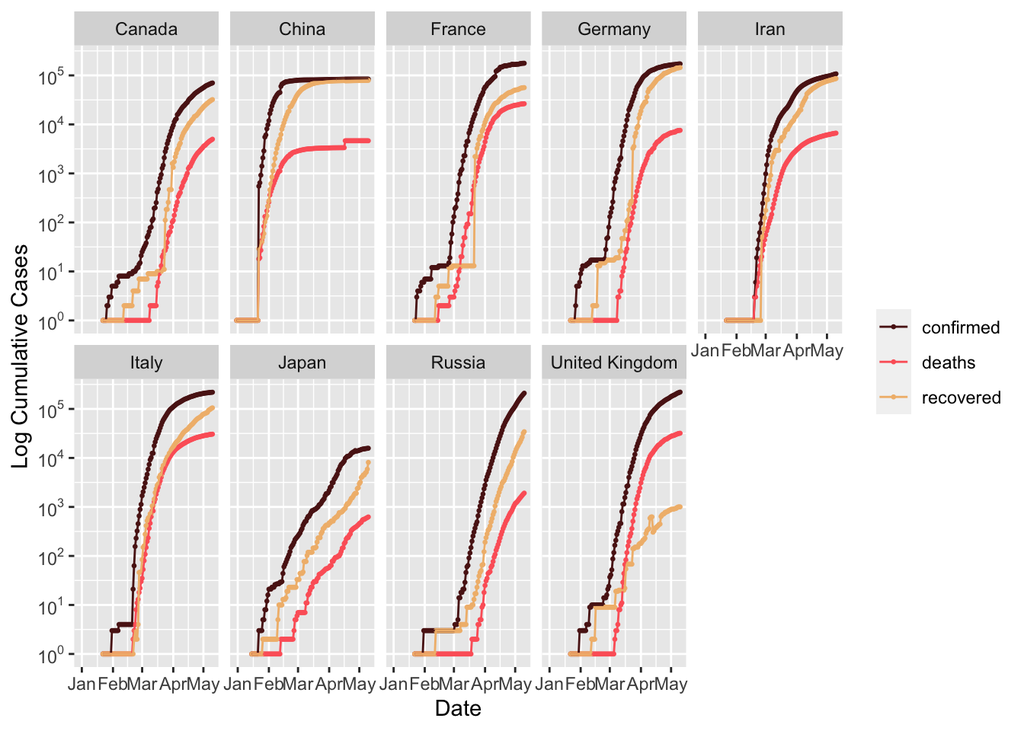

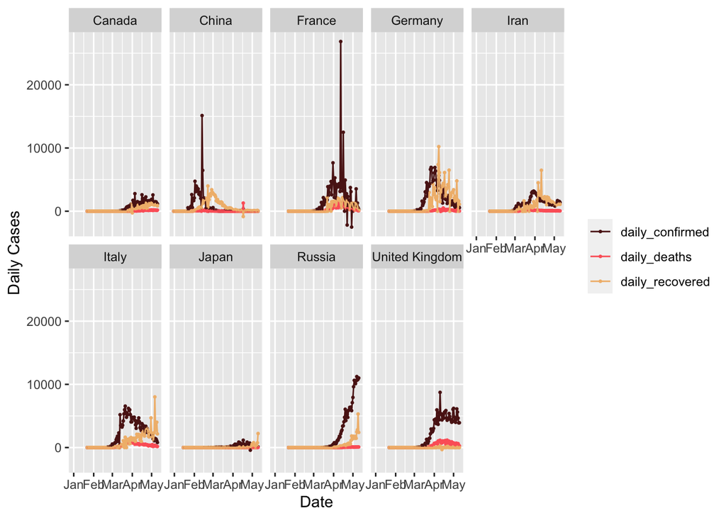

```r
cv_summary(cv_data, country_list = c("US", "United Kingdom", "Canada", "France",
  "Germany", "Italy", "Japan", "China", "Russia", "Iran"), facet = "variable")
```

```
## $totals
## # A tibble: 54 x 13
##    country variable cases population   area density    rate gdp_capita income
##    <chr>   <chr>    <dbl>      <dbl>  <dbl>   <dbl>   <dbl>      <dbl> <chr>
##  1 Canada  confirm… 70091   37057765 9.09e6    4.08 1.89e+3     51392. High …
##  2 Canada  daily_c…  2778   37057765 9.09e6    4.08 7.50e+1     51392. High …
##  3 Canada  daily_d…   251   37057765 9.09e6    4.08 6.77e+0     51392. High …
##  4 Canada  daily_r…  1385   37057765 9.09e6    4.08 3.74e+1     51392. High …
##  5 Canada  deaths    4991   37057765 9.09e6    4.08 1.35e+2     51392. High …
##  6 Canada  recover… 32109   37057765 9.09e6    4.08 8.66e+2     51392. High …
##  7 China   confirm… 84010 1392730000 9.39e6  148.   6.03e+1      7753. Upper…
##  8 China   daily_c… 15136 1392730000 9.39e6  148.   1.09e+1      7753. Upper…
##  9 China   daily_d…  1290 1392730000 9.39e6  148.   9.26e-1      7753. Upper…
## 10 China   daily_r…  3995 1392730000 9.39e6  148.   2.87e+0      7753. Upper…
## # … with 44 more rows, and 4 more variables: life_expectancy <dbl>,
## #   max_sd <dbl>, max_mr <dbl>, on <date>
##
## $cum_cases_plot
```

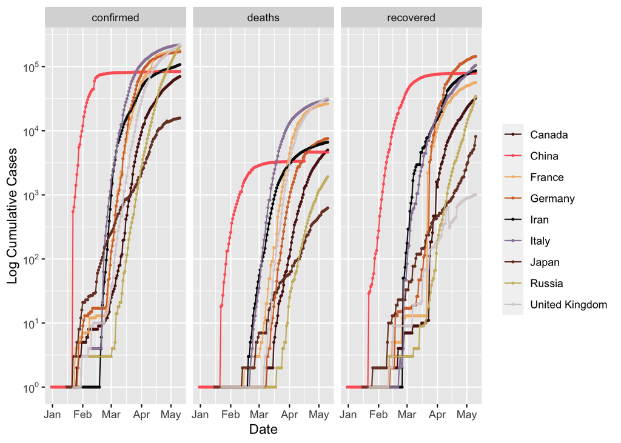

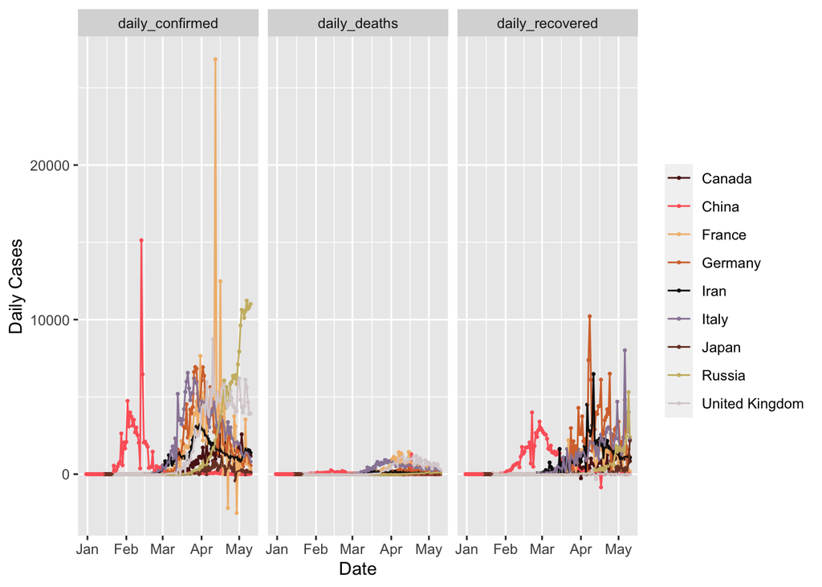

## Challenge 3

```r
d <- cv_summary(cv_data, country_list = "All", plot = FALSE)
d <- d[[1]]
d <- filter(d, population > 1000000)
length(unique(d$country))
```

```
## [1] 154
```

There are 153 countries that have a population over 1,000,000 with confirmed coronavirus cases (Puerto Rico is not a country).

## Challenge 4

```r
overall <- filter(d, variable == "confirmed")
overall <- arrange(overall, desc(rate))
head(overall, 10)
```

```
## # A tibble: 10 x 13
##    country variable  cases population   area density  rate gdp_capita income
##    <chr>   <chr>     <dbl>      <dbl>  <dbl>   <dbl> <dbl>      <dbl> <chr>
##  1 Qatar   confirm… 2.25e4    2781677 1.16e4   240.  8096.     63261. High …
##  2 Spain   confirm… 2.24e5   46796540 5.00e5    93.5 4794.     32950. High …
##  3 Ireland confirm… 2.30e4    4867309 6.89e4    70.5 4725.     76881. High …
##  4 Belgium confirm… 5.31e4   11433256 3.03e4   377.  4643.     47166. High …
##  5 Singap… confirm… 2.33e4    5638676 7.09e2  7953.  4139.     58248. High …
##  6 United… confirm… 1.33e6  326687501 9.15e6    35.8 4069.     54579. High …
##  7 Italy   confirm… 2.19e5   60421760 2.94e5   205.  3626.     35432. High …
##  8 Switze… confirm… 3.03e4    8513227 3.95e4   216.  3560.     79214. High …
##  9 United… confirm… 2.20e5   66460344 2.42e5   275.  3317.     43325. High …
## 10 Bahrain confirm… 4.94e3    1569439 7.78e2  2017.  3148.     21438. High …
## # … with 4 more variables: life_expectancy <dbl>, max_sd <dbl>, max_mr <dbl>,
## #   on <date>
```

```r
overall <- arrange(overall, desc(cases))
head(overall, 10)
```

```
## # A tibble: 10 x 13
##    country variable  cases population   area density  rate gdp_capita income
##    <chr>   <chr>     <dbl>      <dbl>  <dbl>   <dbl> <dbl>      <dbl> <chr>
##  1 United… confirm… 1.33e6  326687501 9.15e6   35.8  4069.     54579. High …
##  2 Spain   confirm… 2.24e5   46796540 5.00e5   93.5  4794.     32950. High …
##  3 United… confirm… 2.20e5   66460344 2.42e5  275.   3317.     43325. High …
##  4 Italy   confirm… 2.19e5   60421760 2.94e5  205.   3626.     35432. High …
##  5 Russia  confirm… 2.10e5  144478050 1.64e7    8.82 1451.     11729. Upper…
##  6 France  confirm… 1.77e5   66977107 5.48e5  122.   2644.     43664. High …
##  7 Germany confirm… 1.72e5   82905782 3.49e5  237.   2073.     47478. High …
##  8 Brazil  confirm… 1.63e5  209469333 8.36e6   25.1   777.     11026. Upper…
##  9 Turkey  confirm… 1.39e5   82319724 7.70e5  107.   1684.     15069. Upper…
## 10 Iran    confirm… 1.08e5   81800269 1.63e6   50.2  1315.      6952. Upper…
## # … with 4 more variables: life_expectancy <dbl>, max_sd <dbl>, max_mr <dbl>,
## #   on <date>
```

```r
daily <- filter(d, variable == "daily_confirmed")
daily <- arrange(daily, desc(rate))
head(daily, 10)
```

```
## # A tibble: 10 x 13
##    country variable cases population   area density  rate gdp_capita income
##    <chr>   <chr>    <dbl>      <dbl>  <dbl>   <dbl> <dbl>      <dbl> <chr>
##  1 Ecuador daily_c… 11536   17084357 2.48e5    68.8  675.      5185. Upper…
##  2 Qatar   daily_c…  1311    2781677 1.16e4   240.   471.     63261. High …
##  3 France  daily_c… 26849   66977107 5.48e5   122.   401.     43664. High …
##  4 Ireland daily_c…  1515    4867309 6.89e4    70.5  311.     76881. High …
##  5 Kuwait  daily_c…  1065    4137309 1.78e4   232.   257.     33112. High …
##  6 Singap… daily_c…  1426    5638676 7.09e2  7953.   253.     58248. High …
##  7 Belgium daily_c…  2454   11433256 3.03e4   377.   215.     47166. High …
##  8 Bahrain daily_c…   330    1569439 7.78e2  2017.   210.     21438. High …
##  9 Spain   daily_c…  9630   46796540 5.00e5    93.5  206.     32950. High …
## 10 Belarus daily_c…  1485    9483499 2.03e5    46.7  157.      6744. Upper…
## # … with 4 more variables: life_expectancy <dbl>, max_sd <dbl>, max_mr <dbl>,
## #   on <date>
```

```r
daily <- arrange(daily, desc(cases))
head(daily, 10)
```

```
## # A tibble: 10 x 13
##    country variable cases population   area density  rate gdp_capita income
##    <chr>   <chr>    <dbl>      <dbl>  <dbl>   <dbl> <dbl>      <dbl> <chr>
##  1 United… daily_c… 36188  326687501 9.15e6   35.8  111.      54579. High …
##  2 France  daily_c… 26849   66977107 5.48e5  122.   401.      43664. High …
##  3 China   daily_c… 15136 1392730000 9.39e6  148.    10.9      7753. Upper…
##  4 Ecuador daily_c… 11536   17084357 2.48e5   68.8  675.       5185. Upper…
##  5 Russia  daily_c… 11231  144478050 1.64e7    8.82  77.7     11729. Upper…
##  6 Brazil  daily_c… 11156  209469333 8.36e6   25.1   53.3     11026. Upper…
##  7 Spain   daily_c…  9630   46796540 5.00e5   93.5  206.      32950. High …
##  8 United… daily_c…  8733   66460344 2.42e5  275.   131.      43325. High …
##  9 Germany daily_c…  6933   82905782 3.49e5  237.    83.6     47478. High …
## 10 Italy   daily_c…  6557   60421760 2.94e5  205.   109.      35432. High …
## # … with 4 more variables: life_expectancy <dbl>, max_sd <dbl>, max_mr <dbl>,
## #   on <date>
```

## Challenge 5

For this challenge, I will filter the dataset **overall** to include just the variables of interest. 5 countries were removed from the dataset due to either NAs or -Inf values. This new dataset is **overall_filt_ex**.

```r
overall <- overall[-154,]
overall_filt <- select(overall, country, population, density, rate, gdp_capita, income)
overall_filt_ex <- na.exclude(overall_filt)
overall_filt_ex <- overall_filt_ex[-149, ]

summary(lm(rate ~ density + population + gdp_capita + income, data = overall_filt_ex))
```

```
##
## Call:
## lm(formula = rate ~ density + population + gdp_capita + income,
##     data = overall_filt_ex)
##
## Residuals:
##     Min      1Q  Median      3Q     Max
## -2537.5  -333.2   -65.3    40.2  5163.1
##
## Coefficients:
##                             Estimate Std. Error t value Pr(>|t|)
## (Intercept)                2.838e+02  2.805e+02   1.012   0.3134
## density                    2.273e-01  1.084e-01   2.097   0.0378 *
## population                -1.048e-07  4.477e-07  -0.234   0.8154
## gdp_capita                 4.102e-02  6.668e-03   6.151 7.49e-09 ***
## incomeLow income          -2.938e+02  3.240e+02  -0.907   0.3661
## incomeLower middle income -2.788e+02  3.071e+02  -0.908   0.3656
## incomeUpper middle income -9.653e+01  2.738e+02  -0.353   0.7250
## ---
## Signif. codes:  0 '***' 0.001 '**' 0.01 '*' 0.05 '.' 0.1 ' ' 1
##
## Residual standard error: 875.6 on 141 degrees of freedom
## Multiple R-squared:  0.532,  Adjusted R-squared:  0.512
## F-statistic: 26.71 on 6 and 141 DF,  p-value: < 2.2e-16
```

Now, I will look at each set of variables individually to determine if a logarithmic transformation is necessary.

```r
summary(lm(rate ~ density, overall_filt_ex))
```

```
##
## Call:
## lm(formula = rate ~ density, data = overall_filt_ex)
##
## Residuals:
##     Min      1Q  Median      3Q     Max
## -1151.4  -667.0  -529.5    96.2  7325.7
##
## Coefficients:
##             Estimate Std. Error t value Pr(>|t|)
## (Intercept) 657.0039   104.1030   6.311 3.13e-09 ***
## density       0.4721     0.1472   3.206  0.00165 **
## ---
## Signif. codes:  0 '***' 0.001 '**' 0.01 '*' 0.05 '.' 0.1 ' ' 1
##
## Residual standard error: 1216 on 146 degrees of freedom
## Multiple R-squared:  0.06578,    Adjusted R-squared:  0.05939
## F-statistic: 10.28 on 1 and 146 DF,  p-value: 0.001652
```

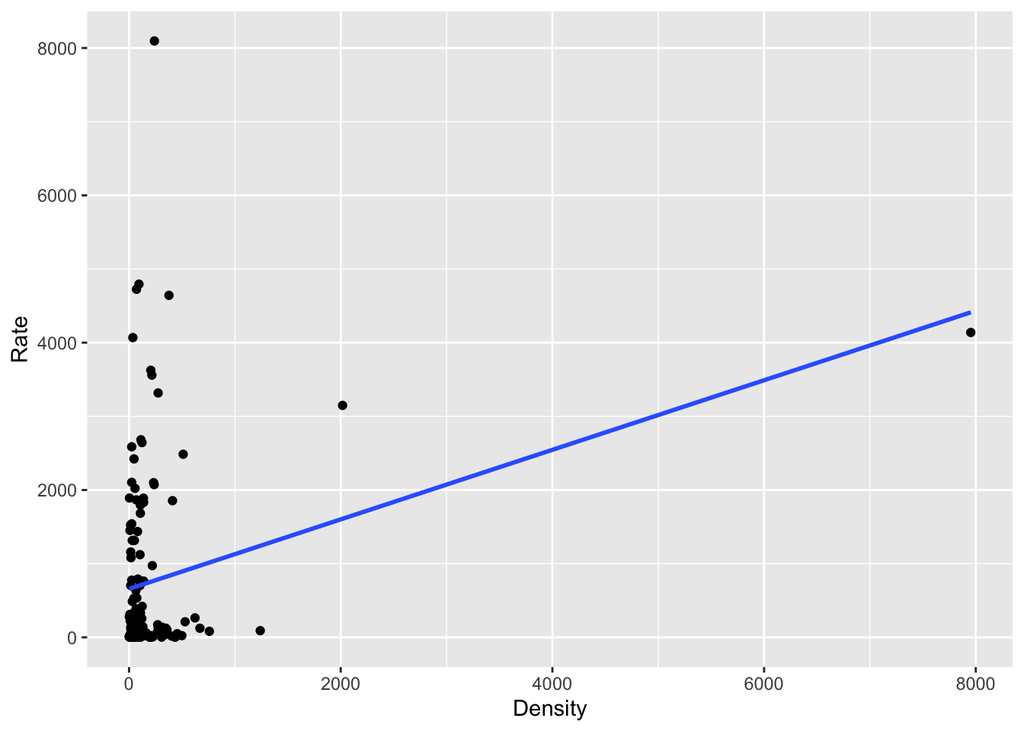

```r
RvD <- ggplot(overall_filt_ex, aes(x = density, y = rate)) +
  geom_point() +
  geom_smooth(method="lm", se = FALSE) +
  xlab("Density") + ylab("Rate")
RvD
```

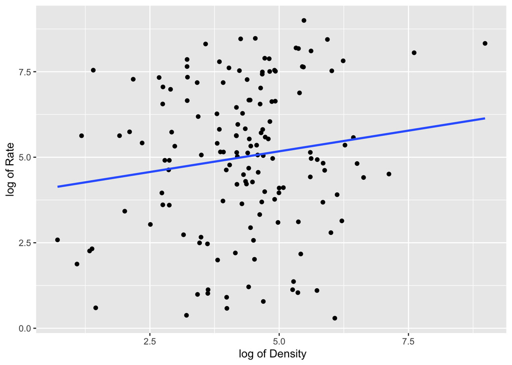

```r
log_RvD <- ggplot(overall_filt_ex, aes(x = log(density), y = log(rate))) +
  geom_point() +
  geom_smooth(method="lm", se = FALSE) +
  xlab(" log of Density") + ylab("log of Rate")
log_RvD
```

```r
summary(lm(log(rate) ~ log(density), overall_filt_ex))
```

```
##
## Call:
## lm(formula = log(rate) ~ log(density), data = overall_filt_ex)
##
## Residuals:
##     Min      1Q  Median      3Q     Max
## -5.1390 -1.3870  0.1317  1.9161  3.7101
##
## Coefficients:
##              Estimate Std. Error t value Pr(>|t|)
## (Intercept)    3.9639     0.6057   6.544 9.49e-10 ***
## log(density)   0.2419     0.1347   1.795   0.0747 .
## ---
## Signif. codes:  0 '***' 0.001 '**' 0.01 '*' 0.05 '.' 0.1 ' ' 1
##
## Residual standard error: 2.159 on 146 degrees of freedom
## Multiple R-squared:  0.0216, Adjusted R-squared:  0.0149
## F-statistic: 3.223 on 1 and 146 DF,  p-value: 0.07466
```

```r
summary(lm(rate ~ population, overall_filt_ex))
```

```
##
## Call:
## lm(formula = rate ~ population, data = overall_filt_ex)
##
## Residuals:
##    Min     1Q Median     3Q    Max
## -765.9 -724.6 -580.9  116.7 7327.5
##
## Coefficients:
##               Estimate Std. Error t value Pr(>|t|)
## (Intercept)  7.694e+02  1.080e+02   7.121 4.51e-11 ***
## population  -3.764e-07  6.342e-07  -0.594    0.554
## ---
## Signif. codes:  0 '***' 0.001 '**' 0.01 '*' 0.05 '.' 0.1 ' ' 1
##
## Residual standard error: 1256 on 146 degrees of freedom
## Multiple R-squared:  0.002407,   Adjusted R-squared:  -0.004426
## F-statistic: 0.3523 on 1 and 146 DF,  p-value: 0.5538
```

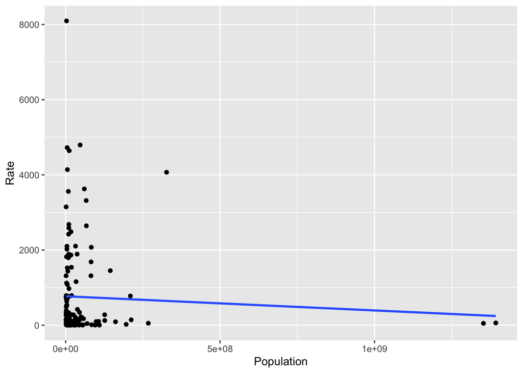

```r
RvP <- ggplot(overall_filt_ex, aes(x = population, y = rate)) +
  geom_point() +
  geom_smooth(method="lm", se = FALSE) +
  xlab("Population") + ylab("Rate")
RvP
```

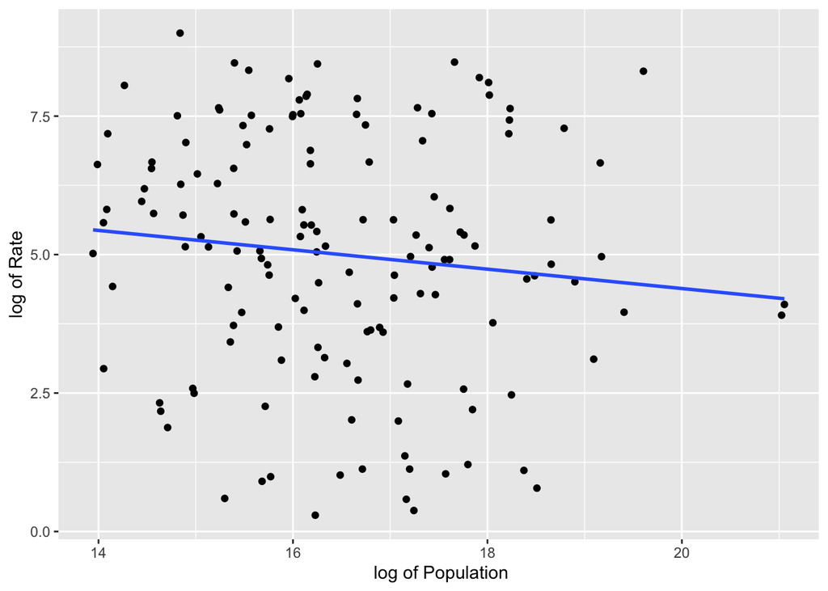

```r
log_RvP <- ggplot(overall_filt_ex, aes(x = log(population), y = log(rate))) +
  geom_point() +
  geom_smooth(method="lm", se = FALSE) +
  xlab(" log of Population") + ylab("log of Rate")
log_RvP
```

```r
summary(lm(log(rate) ~ log(population), overall_filt_ex))
```

```
##
## Call:
## lm(formula = log(rate) ~ log(population), data = overall_filt_ex)
##
## Residuals:
##     Min      1Q  Median      3Q     Max
## -4.7521 -1.3637  0.1147  1.7485  3.8548
##
## Coefficients:
##                 Estimate Std. Error t value Pr(>|t|)
## (Intercept)       7.8843     2.0750   3.800 0.000212 ***
## log(population)  -0.1749     0.1255  -1.393 0.165623
## ---
## Signif. codes:  0 '***' 0.001 '**' 0.01 '*' 0.05 '.' 0.1 ' ' 1
##
## Residual standard error: 2.168 on 146 degrees of freedom
## Multiple R-squared:  0.01312,    Adjusted R-squared:  0.006364
## F-statistic: 1.942 on 1 and 146 DF,  p-value: 0.1656
```

```r
summary(lm(rate ~ gdp_capita, overall_filt_ex))
```

```
##
## Call:
## lm(formula = rate ~ gdp_capita, data = overall_filt_ex)
##
## Residuals:
##     Min      1Q  Median      3Q     Max
## -2917.4  -262.6  -129.3     5.1  5015.4
##
## Coefficients:
##              Estimate Std. Error t value Pr(>|t|)
## (Intercept) 88.894998  89.721935   0.991    0.323
## gdp_capita   0.047290   0.003812  12.404   <2e-16 ***
## ---
## Signif. codes:  0 '***' 0.001 '**' 0.01 '*' 0.05 '.' 0.1 ' ' 1
##
## Residual standard error: 877.7 on 146 degrees of freedom
## Multiple R-squared:  0.5131, Adjusted R-squared:  0.5098
## F-statistic: 153.9 on 1 and 146 DF,  p-value: < 2.2e-16
```

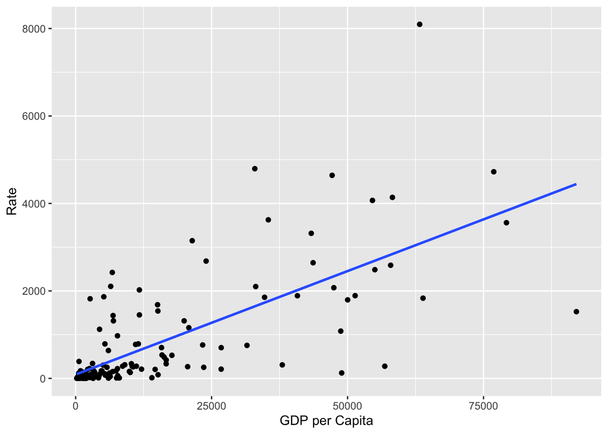

```r
RvG <- ggplot(overall_filt_ex, aes(x = gdp_capita, y = rate)) +
  geom_point() +
  geom_smooth(method="lm", se = FALSE) +
  xlab("GDP per Capita") + ylab("Rate")
RvG
```

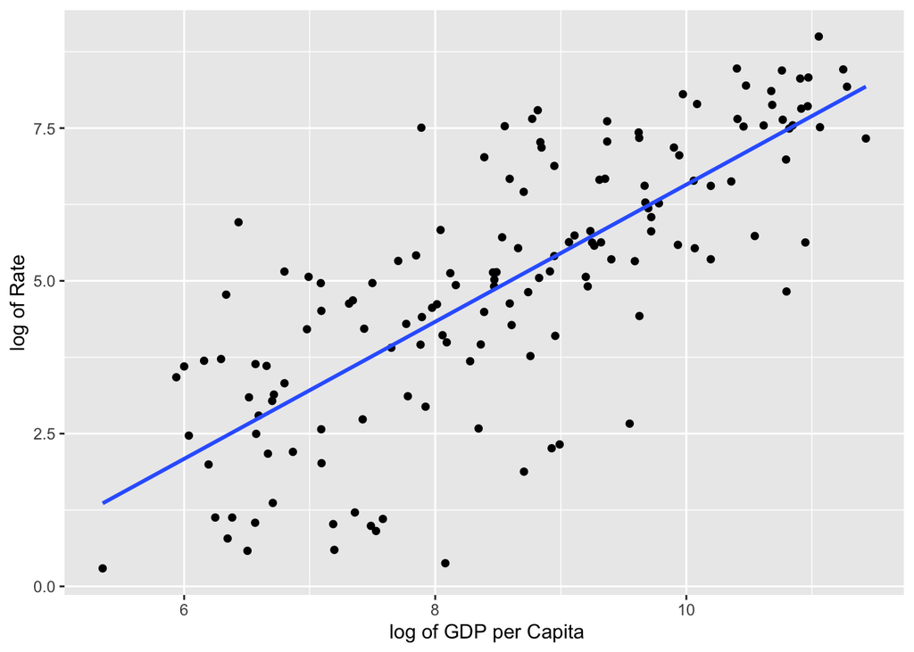

```r
log_RvG <- ggplot(overall_filt_ex, aes(x = log(gdp_capita), y = log(rate))) +
  geom_point() +
  geom_smooth(method="lm", se = FALSE) +
  xlab(" log of GDP per Capita") + ylab("log of Rate")
log_RvG
```

```r
summary(lm(log(rate) ~ log(gdp_capita), overall_filt_ex))
```

```
##
## Call:
## lm(formula = log(rate) ~ log(gdp_capita), data = overall_filt_ex)
##
## Residuals:
##     Min      1Q  Median      3Q     Max
## -4.0422 -0.7802  0.1337  0.9385  3.3862
##
## Coefficients:
##                 Estimate Std. Error t value Pr(>|t|)
## (Intercept)     -4.64449    0.67305  -6.901 1.46e-10 ***
## log(gdp_capita)  1.12196    0.07712  14.547  < 2e-16 ***
## ---
## Signif. codes:  0 '***' 0.001 '**' 0.01 '*' 0.05 '.' 0.1 ' ' 1
##
## Residual standard error: 1.394 on 146 degrees of freedom
## Multiple R-squared:  0.5918, Adjusted R-squared:  0.589
## F-statistic: 211.6 on 1 and 146 DF,  p-value: < 2.2e-16
```

```r
overall_filt_ex$income <- factor(overall_filt_ex$income,
    levels = c('Low income','Lower middle income','Upper middle income','High income'),
    ordered = TRUE)

summary(lm(rate ~ income, overall_filt_ex))
```

```
##
## Call:
## lm(formula = rate ~ income, data = overall_filt_ex)
##
## Residuals:
##     Min      1Q  Median      3Q     Max
## -1815.6  -358.6   -41.2    47.1  6196.7
##
## Coefficients:
##             Estimate Std. Error t value Pr(>|t|)
## (Intercept)   647.80      83.63   7.746 1.55e-12 ***
## income.L     1332.34     171.62   7.763 1.40e-12 ***
## income.Q      645.97     167.27   3.862 0.000169 ***
## income.C      154.49     162.80   0.949 0.344252
## ---
## Signif. codes:  0 '***' 0.001 '**' 0.01 '*' 0.05 '.' 0.1 ' ' 1
##
## Residual standard error: 999 on 144 degrees of freedom
## Multiple R-squared:  0.3779, Adjusted R-squared:  0.3649
## F-statistic: 29.15 on 3 and 144 DF,  p-value: 8.632e-15
```

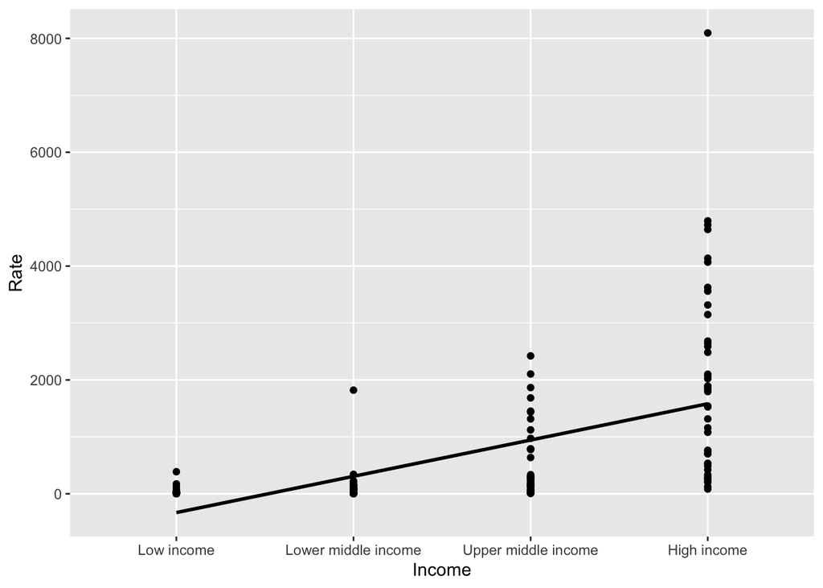

```r
RvI <- ggplot(overall_filt_ex, aes(x = income, y = rate)) +
  geom_point() +
  geom_smooth(method="lm", se = FALSE, aes(group = 1), color = "black") +
  xlab("Income") + ylab("Rate")
RvI
```

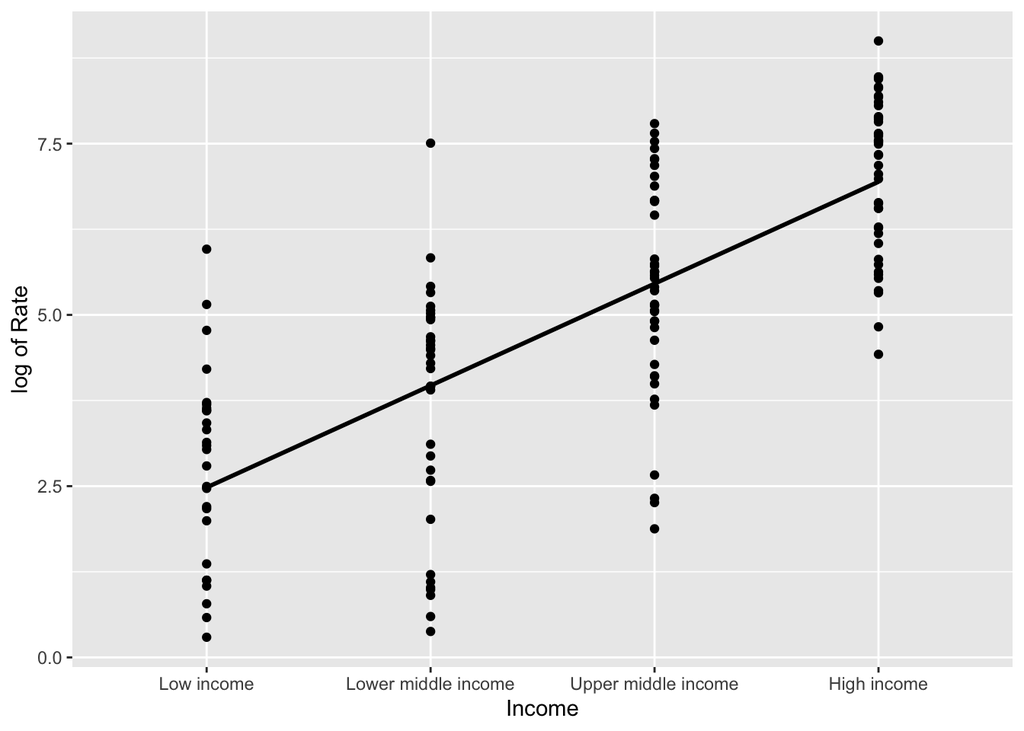

```r
log_RvI <- ggplot(overall_filt_ex, aes(x = income, y = log(rate))) +
  geom_point() +
  geom_smooth(method="lm", se = FALSE, aes(group = 1), color = "black") +
  xlab("Income") + ylab("log of Rate")
log_RvI
```

```r
summary(lm(log(rate) ~ income, overall_filt_ex))
```

```
##
## Call:
## lm(formula = log(rate) ~ income, data = overall_filt_ex)
##
## Residuals:
##     Min      1Q  Median      3Q     Max
## -3.5131 -0.9593  0.2655  0.9952  3.8345
##
## Coefficients:
##             Estimate Std. Error t value Pr(>|t|)
## (Intercept)   4.7243     0.1220  38.723   <2e-16 ***
## income.L      3.2638     0.2503  13.037   <2e-16 ***
## income.Q      0.3858     0.2440   1.581    0.116
## income.C     -0.1925     0.2375  -0.811    0.419
## ---
## Signif. codes:  0 '***' 0.001 '**' 0.01 '*' 0.05 '.' 0.1 ' ' 1
##
## Residual standard error: 1.457 on 144 degrees of freedom
## Multiple R-squared:  0.5603, Adjusted R-squared:  0.5511
## F-statistic: 61.16 on 3 and 144 DF,  p-value: < 2.2e-16
```

Based on these graphs and linear regression analyses, it appears that both income and GDP per capita are significantly correlated with the rate of coronavirus transmission.

## Challenge 6

```r
library(MASS)
overall_lm_opt <- lm(rate ~ log(density) + log(population) + log(gdp_capita) + income,
             data = overall_filt_ex)
overall_AIC <- stepAIC(overall_lm_opt, scope = . ~ ., direction = "both")
```

```
## Start:  AIC=2026.4
## rate ~ log(density) + log(population) + log(gdp_capita) + income
##
##                   Df Sum of Sq       RSS    AIC
## - log(population)  1       172 118984433 2024.4
## <none>                         118984261 2026.4
## - log(density)     1   6129283 125113544 2031.8
## - income           3  13923065 132907326 2036.8
## - log(gdp_capita)  1  18733352 137717613 2046.0
##
## Step:  AIC=2024.4
## rate ~ log(density) + log(gdp_capita) + income
##
##                   Df Sum of Sq       RSS    AIC
## <none>                         118984433 2024.4
## + log(population)  1       172 118984261 2026.4
## - log(density)     1   6229964 125214397 2030.0
## - income           3  13937821 132922254 2034.8
## - log(gdp_capita)  1  19038648 138023081 2044.4
```

```r
library(MuMIn)
r.squaredGLMM(overall_lm_opt)
```

```
##            R2m       R2c
## [1,] 0.4744921 0.4744921
```

```r
r.squaredGLMM(overall_AIC)
```

```
##            R2m       R2c
## [1,] 0.4762539 0.4762539
```

The best model based on the `stepAIC()` function removes the **log(population)** variable. The pseduo-R<sup>2</sup> value slightly increased from 0.4745 to 0.4763.

```r
daily_ex <- na.exclude(daily)
daily_lm_opt <- lm(rate ~ log(density) + log(population) + log(gdp_capita) + income,
             data = daily_ex)
daily_AIC <- stepAIC(daily_lm_opt, scope = . ~ ., direction = "both")
```

```
## Start:  AIC=1307.63
## rate ~ log(density) + log(population) + log(gdp_capita) + income
##
##                   Df Sum of Sq    RSS    AIC
## - income           3     19682 898242 1304.9
## - log(population)  1      5274 883833 1306.5
## <none>                         878560 1307.6
## - log(density)     1     29414 907973 1310.5
## - log(gdp_capita)  1     39487 918046 1312.2
##
## Step:  AIC=1304.93
## rate ~ log(density) + log(population) + log(gdp_capita)
##
##                   Df Sum of Sq     RSS    AIC
## - log(population)  1      6564  904806 1304.0
## <none>                          898242 1304.9
## + income           3     19682  878560 1307.6
## - log(density)     1     32746  930988 1308.3
## - log(gdp_capita)  1    230218 1128460 1336.9
##
## Step:  AIC=1304.02
## rate ~ log(density) + log(gdp_capita)
##
##                   Df Sum of Sq     RSS    AIC
## <none>                          904806 1304.0
## + log(population)  1      6564  898242 1304.9
## + income           3     20973  883833 1306.5
## - log(density)     1     29741  934547 1306.8
## - log(gdp_capita)  1    241309 1146115 1337.2
```

```r
r.squaredGLMM(daily_lm_opt)
```

```
##            R2m       R2c
## [1,] 0.2501466 0.2501466
```

```r
r.squaredGLMM(daily_AIC)
```

```
##            R2m       R2c
## [1,] 0.2333794 0.2333794
```

Repeating this model using the **daily_ex** dataset revealed that the best model does not include the **income** and **log(population)** variables. Therefore, this model is slightly different than when using the **overall_filt_ex** dataset. The pseudo-R<sup>2</sup> value actually decreased from 0.2501 to 0.2334, which was unexpected.

## Challenge 7

```r
daily_lm_max <- lm(data = daily_ex, rate ~ log(density) + log(gdp_capita) + max_sd + max_mr)
daily_AIC_max <- stepAIC(daily_lm_max, scope = . ~ ., direction = "both")
```

```
## Start:  AIC=1304.79
## rate ~ log(density) + log(gdp_capita) + max_sd + max_mr
##
##                   Df Sum of Sq     RSS    AIC
## - max_sd           1      5228  890668 1303.7
## <none>                          885441 1304.8
## - max_mr           1     15710  901151 1305.4
## - log(density)     1     30856  916297 1307.9
## - log(gdp_capita)  1    227620 1113061 1336.9
##
## Step:  AIC=1303.67
## rate ~ log(density) + log(gdp_capita) + max_mr
##
##                   Df Sum of Sq     RSS    AIC
## <none>                          890668 1303.7
## - max_mr           1     14137  904806 1304.0
## + max_sd           1      5228  885441 1304.8
## - log(density)     1     34160  924829 1307.3
## - log(gdp_capita)  1    251563 1142231 1338.7
```

```r
r.squaredGLMM(daily_lm_max)
```

```
##            R2m       R2c
## [1,] 0.2470458 0.2470458
```

```r
r.squaredGLMM(daily_lm_opt)
```

```
##            R2m       R2c
## [1,] 0.2501466 0.2501466
```

## Challenge 8

```r
cv_data_filt <- filter(cv_data,
                       population > 1000000,
                       rate > 1,
                       variable == "daily_confirmed")

library(lme4)
m1 <- lmer(data = cv_data_filt, rate ~ log(density) + log(gdp_capita) + soc_dist +
          mov_rest + (1 | country) + (1 | date))

lme0 <- lmer(data = cv_data_filt, rate ~ (1 | country) + (1 | date), REML = FALSE)
lme1 <- lmer(data = cv_data_filt, rate ~ log(density) + (1 | country) + (1 | date),
             REML = FALSE)
lme2 <- lmer(data = cv_data_filt, rate ~ log(gdp_capita) + (1 | country) + (1 | date),
             REML = FALSE)
lme3 <- lmer(data = cv_data_filt, rate ~ soc_dist + (1 | country) + (1 | date),
             REML = FALSE)
lme4 <- lmer(data = cv_data_filt, rate ~ mov_rest + (1 | country) + (1 | date),
             REML = FALSE)
lme5 <- lmer(data = cv_data_filt, rate ~ log(density) + log(gdp_capita) + soc_dist +
          mov_rest + (1 | country) + (1 | date), REML = FALSE)
lme6 <- lmer(data = cv_data_filt, rate ~ log(density) + log(gdp_capita) + soc_dist +
            (1 | country) + (1 | date), REML = FALSE)
lme7 <- lmer(data = cv_data_filt, rate ~ log(density) + log(gdp_capita) + mov_rest +
            (1 | country) + (1 | date), REML = FALSE)
lme8 <- lmer(data = cv_data_filt, rate ~ log(density) + soc_dist + mov_rest +
            (1 | country) + (1 | date), REML = FALSE)
lme9 <- lmer(data = cv_data_filt, rate ~ log(gdp_capita) + soc_dist + mov_rest +
            (1 | country) + (1 | date), REML = FALSE)
lme10 <- lmer(data = cv_data_filt, rate ~ log(density) + log(gdp_capita) + (1 | country) +
            (1 | date), REML = FALSE)
lme11 <- lmer(data = cv_data_filt, rate ~ log(density) + soc_dist + (1 | country) +
            (1 | date), REML = FALSE)
lme12 <- lmer(data = cv_data_filt, rate ~ log(density) + mov_rest + (1 | country) +
            (1 | date), REML = FALSE)
lme13 <- lmer(data = cv_data_filt, rate ~ log(gdp_capita) + soc_dist + (1 | country) +
            (1 | date), REML = FALSE)
lme14 <- lmer(data = cv_data_filt, rate ~ log(gdp_capita) + mov_rest + (1 | country) +
            (1 | date), REML = FALSE)
lme15 <- lmer(data = cv_data_filt, rate ~ soc_dist + mov_rest + (1 | country) +
            (1 | date), REML = FALSE)

library(AICcmodavg)
lme_aic <- aictab(list(lme0, lme1, lme2, lme3, lme4, lme5, lme6, lme7, lme8, lme9, lme10,
                       lme11, lme12, lme13, lme14, lme15))
lme_aic
```

```
##
## Model selection based on AICc:
##
##       K     AICc Delta_AICc AICcWt Cum.Wt        LL
## Mod7  7 48630.80       0.00   0.73   0.73 -24308.39
## Mod6  8 48632.80       2.00   0.27   1.00 -24308.39
## Mod14 6 48759.68     128.89   0.00   1.00 -24373.83
## Mod10 7 48761.68     130.89   0.00   1.00 -24373.83
## Mod12 6 48844.09     213.30   0.00   1.00 -24416.04
## Mod9  7 48845.99     215.19   0.00   1.00 -24415.98
## Mod4  5 48975.41     344.61   0.00   1.00 -24482.70
## Mod16 6 48977.19     346.40   0.00   1.00 -24482.59
## Mod11 6 48990.09     359.30   0.00   1.00 -24489.04
## Mod8  7 48990.94     360.15   0.00   1.00 -24488.46
## Mod3  5 49122.01     491.21   0.00   1.00 -24556.00
## Mod15 6 49123.24     492.45   0.00   1.00 -24555.61
## Mod13 6 49243.72     612.92   0.00   1.00 -24615.85
## Mod5  5 49377.46     746.67   0.00   1.00 -24683.73
## Mod2  5 49752.86    1122.06   0.00   1.00 -24871.42
## Mod1  4 49886.45    1255.65   0.00   1.00 -24939.22
```

The best model from this analysis is **lme6** which only excludes the variable **mov_rest** from the model.

```r
r.squaredGLMM(lme6)
```

```
##            R2m       R2c
## [1,] 0.2866913 0.5365689
```

```r
r.squaredGLMM(lme1)
```

```
##             R2m       R2c
## [1,] 0.01299678 0.4685929
```